# AN588-Week-4

Jess Martin

2023-09-28

Module 08 (Probabilities and Distributions)

Recap of Important Terms and Concepts:

- Population = includes all of the elements from a set of data = N
- Sample = one or more observations from a population = n
- Parameter = a measurable characteristic of a population
- Statistic = a measureable characteristic about a sample

When we do statistical inference we are basically trying to draw conclusions about a population based on measurements from a noisy sample or trying to evaluate whether it is reasonable to assume that our sample is drawn from a particular population.

This process of trying to draw conclusions is complicated by the fact that…

- Our sample may be biased, non-random, or non-representative in some way
- There may be unknown or unobserved variables that impact how the sample is related to the population
- The assumptions we make about the population that our sample is drawn from might not be correct

Probability:

The term probability is applied to population level variables that describe the magnitude of chance associated with particular observations or event. Probabilities summarize the relative frequencies of possible outcomes. Probabilities are properties of distributions. Probabilities vary between zero and one. Outcomes that are impossible have Pr = 0, those that are certain have Pr = 1.

- Example: if we roll a (fair) die, there are 6 possible outcomes, each has a probability of occurring of 1 in 6. This is referred to as a frequentist or classical way of thinking about the probability of different outcomes… the relative frequency with which an event occurs over numerous identical, objective trials.
- Example: Rolling a Die

We will use the {manipulate} package and the sample() function to explore the effects of sample size on estimates of the probability of different outcomes. The probability of each outcome (rolling a “1”, “2”,…, “6”) is 1 in 6, but our estimate of the probability of each possible outcome will change with sample size.

(R Challenge 1)

- Write a function to simulate rolling a die where you pass the number of rolls as an argument. Then, use your function to simulate rolling two dice 1000 times and take the sum of the rolls. Plot a histogram of those results.

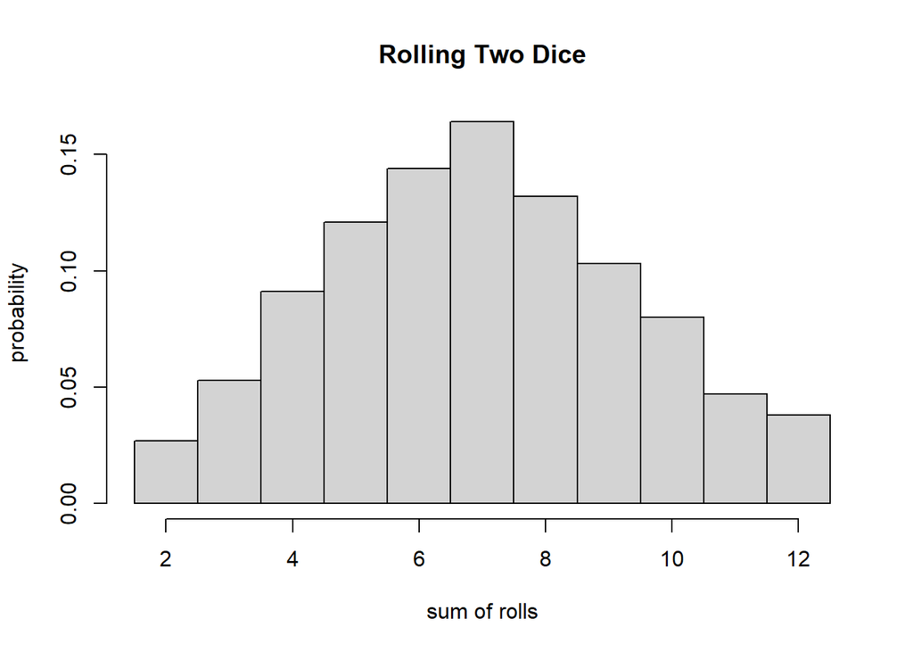

```r
nrolls <- 1000
roll <- function(x) {
    sample(1:6, x, replace = TRUE)
}
two_dice <- roll(nrolls) + roll(nrolls)
hist(two_dice, breaks = c(1.5:12.5), probability = TRUE, main = "Rolling Two Dice",
    xlab = "sum of rolls", ylab = "probability")
```

Rules of Probability:

1.Pr(+) = Probability that something occurs = 1

2.Pr(∅) = Probability that nothing occurs = 0

3.Pr (A) = Probability that a particular event A occurs

0 ≤ Pr (A) ≤ 1

4.Pr (A ⋃ B) = Probability that a particular event A or a particular event B occurs = UNION

Pr (A ⋃ B)= Pr (A) + Pr (B) - Pr (A ⋂ B)

If event A and B are mutually exclusive, then this simplifies to Pr (A) + Pr (B)

5.Pr (A ⋂ B) = Probability that both A and B occur simultaneously = INTERSECTION

Pr (A ⋂ B) = Pr (A|B) × Pr (B) = Pr (B|A) × Pr (A)

where the pipe operator ( | ) can be read as “given”.

If the 2 events are independent (i.e., if the probability of one does not depend on the probability of the other), then Pr (A ⋂ B) simplifies to…

Pr (A) × Pr (B)

If Pr (A ⋂ B) = 0, then we say the events are mutually exclusive (e.g., you cannot have a die roll be 1 and 2)

6.Pr (Ā) = Probability of the complement of A (i.e., not A) = 1 - Pr (A)

7.Conditional Probability is the probability of an event occuring after taking into account the occurrence of another event, i.e., one event is conditioned on the occurrence of a different event.

For example, the probability of a die coming up as a “1” given that we know the die came up as an odd number (“1”, “3”, or “5”).

Pr (A|B) = Pr (A ⋂ B) ÷ Pr (B)

If event A and event B are independent, then Pr (A|B)= [Pr (A) × Pr (B)] ÷ Pr (B) = Pr (A)

If event A and B are dependent, then Pr (A|B) ≠ Pr (A)

(R Challenge 2)

- You have a deck of 52 cards, Ace to 10 + 3 face cards in each suit. You draw a card at random.
- What is the probability that you draw a face card?

```r
#Total number of cards in the deck
total_cards <- 52

#Number of face cards in each suit (3 face cards x 4 suits)
face_cards_per_suit <- 3

#Total number of face cards in the deck
total_face_cards <- face_cards_per_suit * 4

#Probability of drawing a face card
probability_face_card <- total_face_cards / total_cards

cat("Probability of drawing a face card:", probability_face_card, "\n")
```

```
## Probability of drawing a face card: 0.2307692
```

- What is the probability that you draw a King?

```r
#Total number of cards in the deck
total_cards <- 52

#Number of Kings in the deck (4 Kings, one in each suit)
kings_in_deck <- 4

#Probability of drawing a King
probability_king <- kings_in_deck / total_cards

cat("Probability of drawing a King:", probability_king, "\n")
```

```
## Probability of drawing a King: 0.07692308
```

- What is the probability that you draw a spade?

```r
#Total number of cards in the deck
total_cards <- 52

#Number of spades in the deck (13 spades)
spades_in_deck <- 13

#Probability of drawing a spade
probability_spade <- spades_in_deck / total_cards

cat("Probability of drawing a spade:", probability_spade, "\n")
```

```
## Probability of drawing a spade: 0.25
```

- What is the probability that you draw a spade given that you draw a face card?

```r
#Total number of cards in the deck
total_cards <- 52

#Number of face cards in each suit (3 face cards x 4 suits)
face_cards_per_suit <- 3

#Number of spades in the deck (13 spades)
spades_in_deck <- 13

#Number of face cards that are spades (3 face cards)
spades_face_cards <- 3

#Probability of drawing both a spade and a face card
probability_spade_and_face <- (spades_face_cards / total_cards)

#Calculate the conditional probability
conditional_probability <- probability_spade_and_face / (face_cards_per_suit * 4 / total_cards)

cat("Conditional Probability (Spade given Face Card):", conditional_probability, "\n")
```

```
## Conditional Probability (Spade given Face Card): 0.25
```

- What is the probability that you draw a King given that you draw a face card?

```r
# Total number of cards in the deck
total_cards <- 52

# Number of face cards in each suit (3 face cards x 4 suits)
face_cards_per_suit <- 3

# Number of Kings in the deck (4 Kings, one in each suit)
kings_in_deck <- 4

# Number of face cards that are Kings (4 Kings)
kings_face_cards <- 4

# Probability of drawing both a King and a face card
probability_king_and_face <- (kings_face_cards / total_cards)

# Calculate the conditional probability
conditional_probability <- probability_king_and_face / (face_cards_per_suit * 4 / total_cards)

cat("Conditional Probability (King given Face Card):", conditional_probability, "\n")
```

```
## Conditional Probability (King given Face Card): 0.3333333
```

- What is the probability that you draw a card that is both from a red suit (hearts or diamonds) and a face card?

Pr (A) = red suit = 26/52 = 1/2

Pr (B) = face card = 12/52 =

Pr (A|B) = red suit given face card = 6/12

Pr (A ⋂ B) = Pr (A|B) × Pr (B) = 6/12 × 12/52 = 6/52 = 0.1153846

- What is the probability that you draw a card that is either a club or not a face card?

Pr (A) = club = 13/52 = 13/52

Pr (B) = not a face card = 40/52

Pr (A ⋂ B) = club and not a face card = 10/52

Pr (A ⋃ B) = Pr (A) + Pr (B) - Pr (A ⋂ B)= 13/52 + 40/52 - 10/52 = 43/52

Random Variables:

- A random variable is a variable whose outcomes are assumed to arise by chance or according to some random or stochastic mechanism. The chances of observing a specific outcome or an outcome value within a specific interval has associated with it a probability.

Random variables come in two varieties:

- Discrete Random Variables are random variables that can assume only a countable number of discrete possibilities (e.g., counts of outcomes in a particular category). We can assign a probability to each possible outcome.
- Continuous Random Variables are random variables that can assume any real number value within a given range (e.g., measurements). We cannot assign a specific probability to each possible outcome value as the set of possible outcomes is infinite, but we can assign probabilites to intervals of outcome values.

With these basics in mind, we can define a few more terms:

- A probability function is a mathematical function that describes the chance associated with a random variable having a particular outcome or falling within a given range of outcome values.

We can also distinguish two types of probability functions:

1.Probability Mass Functions (PMFs) are associated with discrete random variables. These functions describe the probability that a random variable takes a particular discrete value.

To be a valid PMF, a function f(x) must satisfy the following:

1.There are k distinct outcomes x1,x2,…,xk 2.0 ≤ Pr (X=xi) ≤ 1 for all xi 3.∑ Pr (X=xi) for all x from x1 to xk = 1

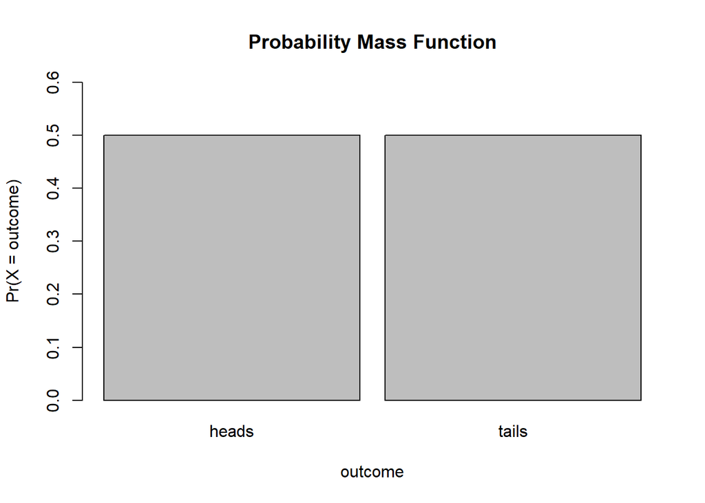

```r
outcomes <- c("heads", "tails")
prob <- c(1/2, 1/2)
barplot(prob, ylim = c(0, 0.6), names.arg = outcomes, space = 0.1, xlab = "outcome",
    ylab = "Pr(X = outcome)", main = "Probability Mass Function")
```

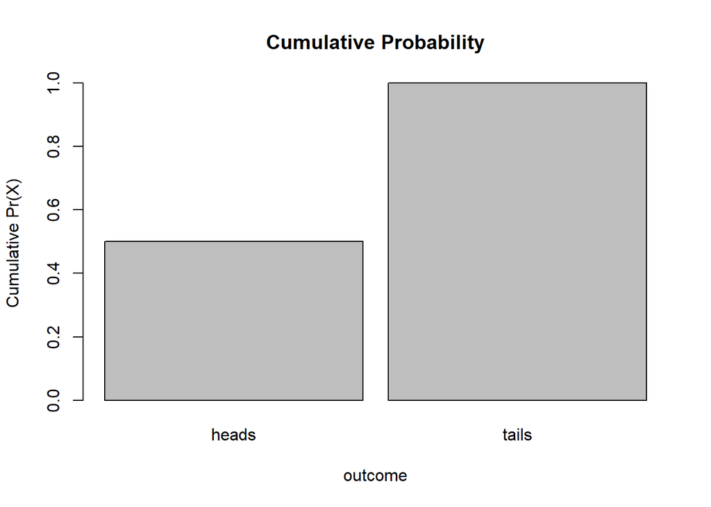

```r
cumprob <- cumsum(prob)
barplot(cumprob, names.arg = outcomes, space = 0.1, xlab = "outcome", ylab = "Cumulative Pr(X)",
    main = "Cumulative Probability")
```

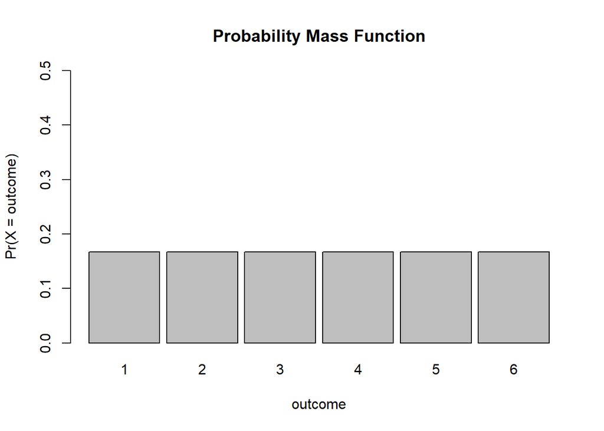

```r
outcomes <- c(1, 2, 3, 4, 5, 6)
prob <- c(1/6, 1/6, 1/6, 1/6, 1/6, 1/6)
barplot(prob, ylim = c(0, 0.5), names.arg = outcomes, space = 0.1, xlab = "outcome",
    ylab = "Pr(X = outcome)", main = "Probability Mass Function")
```

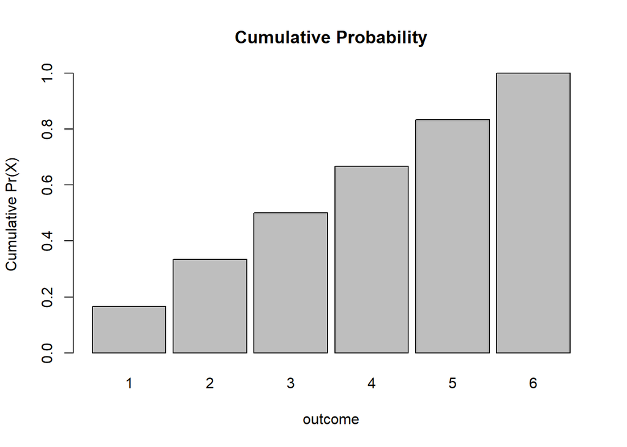

```r
cumprob <- cumsum(prob)
barplot(cumprob, names.arg = outcomes, space = 0.1, xlab = "outcome", ylab = "Cumulative Pr(X)",
    main = "Cumulative Probability")
```

2.Probability Density Functions (PDFs) are associated with continuous random variables. These functions describe the probability that a random variable falls within a given range of outcome values. The probability associated with that range equals the area under the density function for that range.

To be a valid PDF, a function f(x) must satisfy the following:

1.f(x) ≥ 0 for all −∞ ≤ x ≤ +∞. That is, the function f(x) is non-negative everywhere. 2.∫+∞−∞ f(x) dx = 1. That is, the total area under the function f(x) = 1

An Example

The Beta Distribution refers to a family of continuous probability distributions defined over the interval [0, 1] and parametrized by two positive shape parameters, denoted by α and β, that appear as exponents of the random variable x and control the shape of the distribution.

f(x) = K x α−1(1−x)β−1

If we set K = 2, α = 2, and β = 1 and restrict the domain of x to [0, 1], it gives us a triangular function that we can graph as follows:

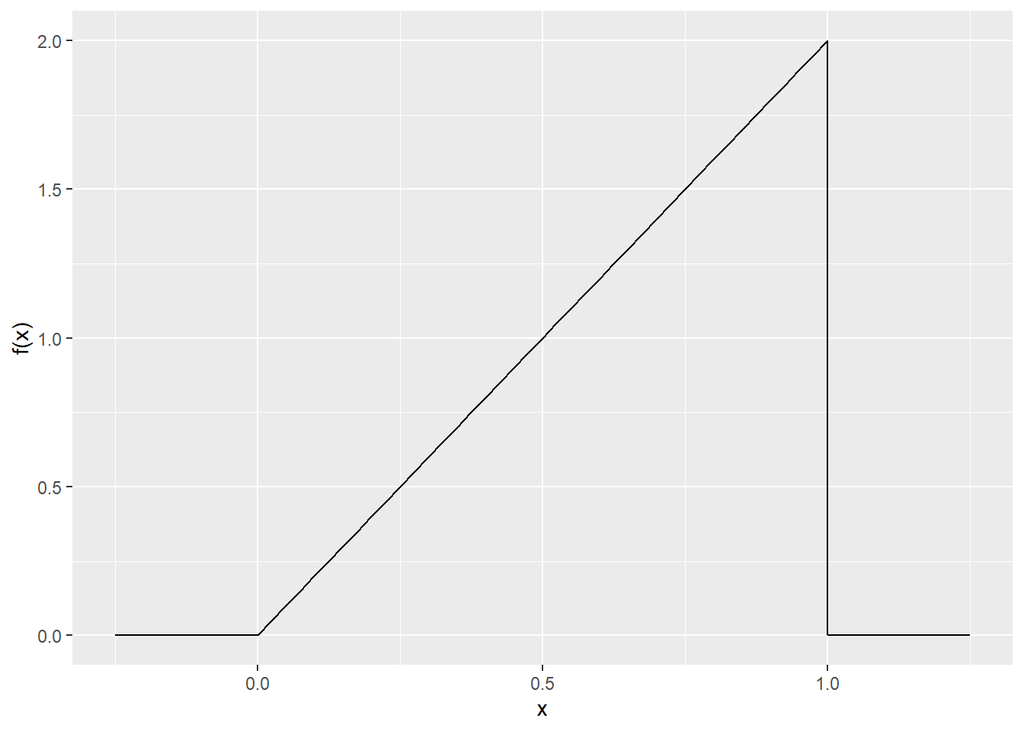

```r
library(ggplot2)
a <- 2
b <- 1
K <- 2
x <- seq(from = 0, to = 1, by = 0.025)
fx <- K * x^(a - 1) * (1 - x)^(b - 1)
lower_x <- seq(from = -0.25, to = 0, by = 0.025)  # add some values of x less than zero
upper_x <- seq(from = 1, to = 1.25, by = 0.025)  # add some values of x greater than one
lower_fx <- rep(0, 11)  # add fx=0 values to x<0
upper_fx <- rep(0, 11)  # add fx=0 values to x>1
x <- c(lower_x, x, upper_x)  # paste xs together
fx <- c(lower_fx, fx, upper_fx)  # paste fxs together
d <- as.data.frame(cbind(x, fx))
p <- ggplot(data = d, aes(x = x, y = fx)) + xlab("x") + ylab("f(x)") + geom_line()
p
```

Is this a PDF? Why or why not? Yes… it satisfies both criteria for a PDF.

f(x) ≥ 0 for all −∞ ≤ x ≤ +∞

The total area under f(x) = 1

The shaded area here represents the cumulative probability integrated across f(x) from −inf to x.

The cumulative distribution function, or CDF, of a random variable is defined as the probability of observing a random variable X taking the value of x or less, i.e., F(x) = Pr (X ≤ x).

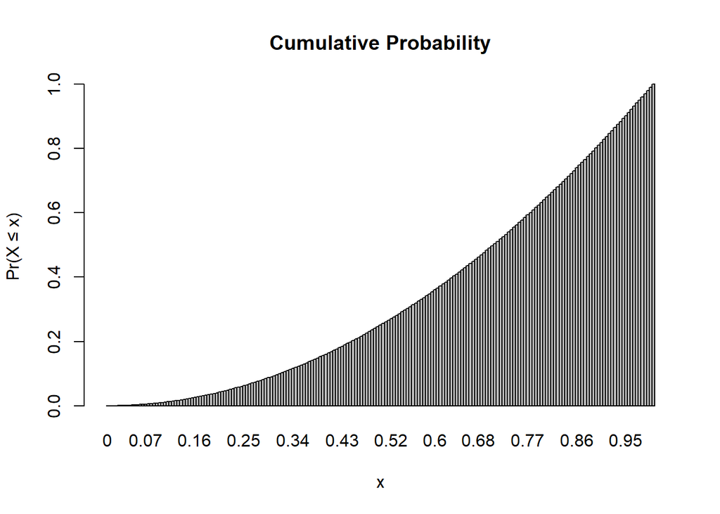

```r
x <- seq(from = 0, to = 1, by = 0.005)
prob <- 0.5 * x * K * x^(a - 1) * (1 - x)^(b - 1)
barplot(prob, names.arg = x, space = 0, main = "Cumulative Probability", xlab = "x",
    ylab = "Pr(X ≤ x)")
```

The built in R function for the Beta Distribution, pbeta(), can give us the cumulative probability directly, if we specify the values of α = 2 and β = 1.

```r
pbeta(0.75, 2, 1)  # cumulative probability for x ≤ 0.75
```

```
## [1] 0.5625
```

```r
pbeta(0.5, 2, 1)  # cumulative probability for x ≤ 0.50
```

```
## [1] 0.25
```

- In general, we find the cumulative probability for a continuous random variable by calculating the area under the probability density function of interest from −∞ to x. This is what is is being returned from pbeta(). The other related Beta Distribution functions, e.g., rbeta(), dbeta(), and qbeta(), are also useful. rbeta() draws random observations from a specfied beta distribution. dbeta() gives the point estimate of the beta density function at the value of the argument x, and qbeta() is essentially the converse of pbeta(), i.e., it tells you the value of x that is associated with a particular cumulative probability, or quantile, of the cumulative distribution function. Other PMFs and PDFs have comparable r, d, p, and q functions.

Note the relationship between the p and q functions:

```r
pbeta(0.7, 2, 1)  # yields .49
```

```
## [1] 0.49
```

```r
qbeta(0.49, 2, 1)  # yield 0.7
```

```
## [1] 0.7
```

We can define the survival function for a random variable X as S(x) = Pr (X > x)= 1 - Pr (X ≤ x) = 1 - f(x)

Finally, we can define the “qth”” quantile of a cumulative distibution function as the value of x at which the CDF has the value “q”, i.e., F(xq)=q.

Expected Mean and Variance of Random Variables:

The mean value (or expectation) and the expected variance for a random variable with a given probability mass function can be expressed generally as follows:

μX = Expectation for X= ∑ xi × Pr (X=xi) for all x from xi to xk

σ2X = Variance of X = ∑ (xi−μX)2 × Pr (X=xi) for all x from xi to xk

Applying these formulae to die rolls, we could calculate the expectation for X for a large set of die rolls…

(1 * 1/6) + (2 * 1/6) + … + (6 * 1/6) = 3.5

```r
m <- sum(seq(1:6) * 1/6)
m
```

```
## [1] 3.5
```

And the expected variance…

[(1 - 3.5)^2 * (1/6)] + [(2 - 3.5)^2 * (1/6)] + … + [(6 - 3.5)^2 * (1/6)] =

```r
var <- sum((seq(1:6) - mean(seq(1:6)))^2 * (1/6))
var
```

```
## [1] 2.916667
```

Likewise, we can calculate the expectation and variance for a random varible X with a given probability density function generally as follows:

μX = Expectation for X = ∫+∞−∞ x f(x) dx

σ2X = Variance of X = ∫+∞−∞ (x−μX)2 f(x) dx

To demonstrate these numerically would require a bit of calculus, i.e., integration.

Useful Probability Distributions for Random Variables:

Probability Mass Functions

The Bernoulli Distribution:

The Bernoulli Distribution is the probability distribution of a binary random variable, i.e., a variable that has only two possible outcomes, such as success or failure, heads or tails, true or false. If p is the probability of one outcome, then 1−p has to be the probabilty of the alternative. For flipping a fair coin, for example, p = 0.5 and 1−p also = 0.5.

For the BERNOULLI DISTRIBUTION, the probability mass function is:

f(x) = px(1−p)1−x where x = {0 or 1}

For this distribution, μX = p and σ2X = p(1−p)

(R Challenge 3)

Using the Bernoulli distribution, calculate the expectation for drawing a spade from a deck of cards? What is the variance in this expectation across a large number of draws?

Pr (spade) = (13/52)1 × (39/52)0 = 0.25

Var (spade) = (13/52) × (1−13/52) = (0.25) × (0.75) = 0.1875

Binomial Distribution:

The Bernoulli distribution is a special case of the Binomial Distribution. The binomial distribution is typically used to model the probability of a number of “successes” k out of a set of “trials” n, i.e., for counts of a particular outcome.

Again, the probability of success on each trial = p and the probability of not success = 1−p.

For the BINOMIAL DISTRIBUTION, the probability mass function is:

This is read as “n choose k”, i.e., the probability of k successes out of n trials. This is also called the “binomial coefficient”.

For this distribution, μX = np and σ2X = np(1-p). Recall, μX = expected number of successes in n trials

Where n = 1, this simplifies to the Bernoulli distribution.

(R Challenge 4)

```r
n <- 6  # number of trials
k <- 6  # number of successes
p <- 1/6
prob <- (factorial(n)/(factorial(k) * factorial(n - k))) * (p^k) * (1 - p)^(n -
    k)
prob
```

```
## [1] 2.143347e-05
```

```r
k <- 3  # number of successes
prob <- (factorial(n)/(factorial(k) * factorial(n - k))) * (p^k) * (1 - p)^(n -
    k)
prob
```

```
## [1] 0.05358368
```

- As for other distributions, R has a built in density function, the dbinom() function, that you can use to solve for the probability of a given outcome, i.e., Pr (X=x).

```r
dbinom(x = k, size = n, prob = p)
```

```
## [1] 0.05358368
```

- We can also use the built in function pbinom() to return the value of the cumulative distribution function for the binomial distribution, i.e., the probability of observing up to and including a given number of successes in n trials.
- So, for example, the chances of observing exactly 0, 1, 2, 3, … 6 rolls of “1” on 6 rolls of a die are…

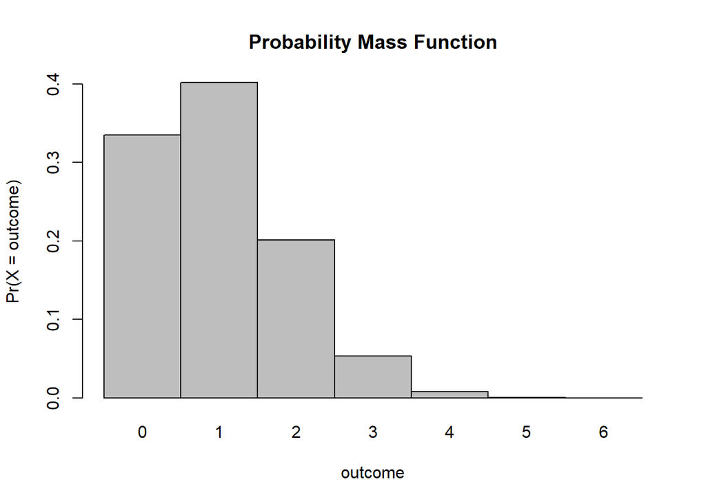

```r
probset <- dbinom(x = 0:6, size = 6, prob = 1/6)  # x is number of successes, size is number of trials
barplot(probset, names.arg = 0:6, space = 0, xlab = "outcome", ylab = "Pr(X = outcome)",
    main = "Probability Mass Function")
```

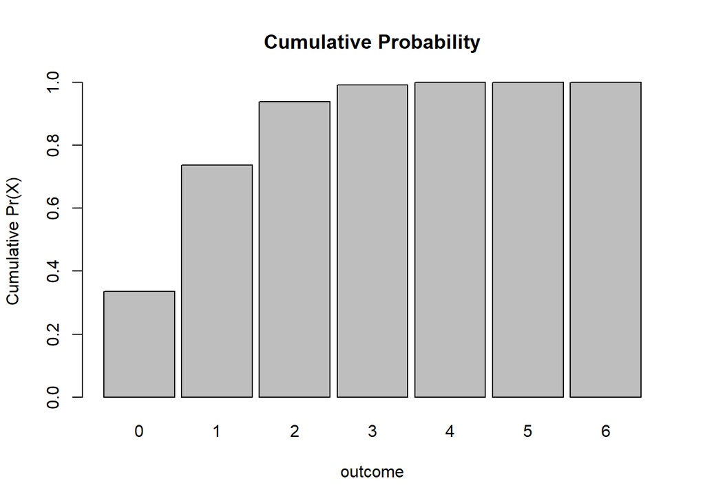

```r
cumprob = cumsum(probset)
barplot(cumprob, names.arg = 0:6, space = 0.1, xlab = "outcome", ylab = "Cumulative Pr(X)",
    main = "Cumulative Probability")
```

```r
sum(probset)  # equals 1, as it should
```

```
## [1] 1
```

The chance of observing exactly 3 rolls of “1” is…

```r
dbinom(x = 3, size = 6, prob = 1/6)
```

```
## [1] 0.05358368
```

And the chance of observing up to and including 3 rolls of “1” is…

```r
pbinom(q = 3, size = 6, prob = 1/6)  # note the name of the argument is q not x
```

```
## [1] 0.991298
```

… which can also be calculated by summing the relevant individual outcome probabilities…

```r
sum(dbinom(x = 0:3, size = 6, prob = 1/6))  # this sums the probabilities of 0, 1, 2, and 3 successes
```

```
## [1] 0.991298
```

```r
1 - pnbinom(q = 3, size = 6, prob = 1/6)
```

```
## [1] 0.9988642
```

or, alternatively…

```r
pnbinom(q = 3, size = 6, prob = 1/6, lower.tail = FALSE)
```

```
## [1] 0.9988642
```

The probability of observing 3 or more rolls of “1” is…

```r
1 - pbinom(q = 2, size = 6, prob = 1/6)  # note here that the q argument is '2'
```

```
## [1] 0.06228567
```

or, alternatively…

```r
pbinom(q = 2, size = 6, prob = 1/6, lower.tail = FALSE)
```

```
## [1] 0.06228567
```

Poisson Distribution:

- The Poisson Distribution is often used to model open ended counts of independently occuring events, for example the number of cars that pass a traffic intersection over a given interval of time or the number of times a monkey scratches itself during a given observation interval. The probability mass function for the Poisson distribution is described by a single parameter, λ, where λ can be interpreted as the mean number of occurrences of the event in the given interval.

The probability mass function for the POISSON DISTRIBUTION is:

For this distribution, μX = λ and σ2X = λ

Note that the mean and the variance are the same!

Let’s use R to look at the probability mass functions for different values of λ:

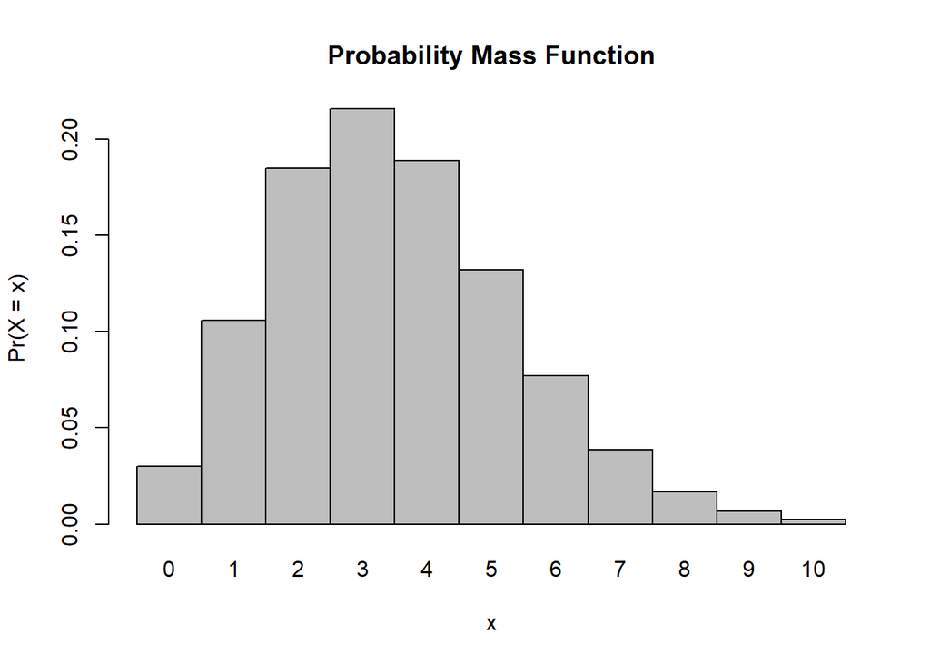

```r
x <- 0:10
l = 3.5
probset <- dpois(x = x, lambda = l)
barplot(probset, names.arg = x, space = 0, xlab = "x", ylab = "Pr(X = x)", main = "Probability Mass Function")
```

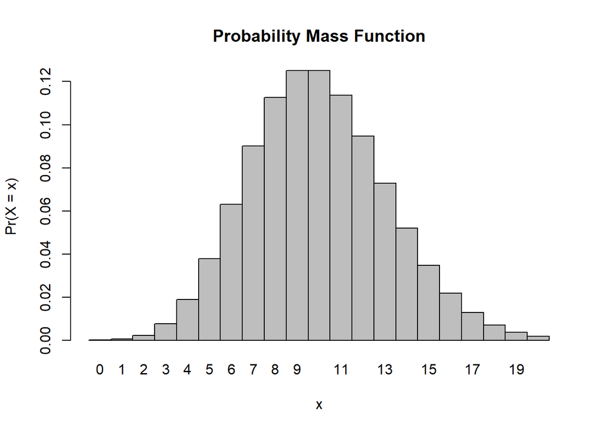

```r
x <- 0:20
l = 10
probset <- dpois(x = x, lambda = l)
barplot(probset, names.arg = x, space = 0, xlab = "x", ylab = "Pr(X = x)", main = "Probability Mass Function")
```

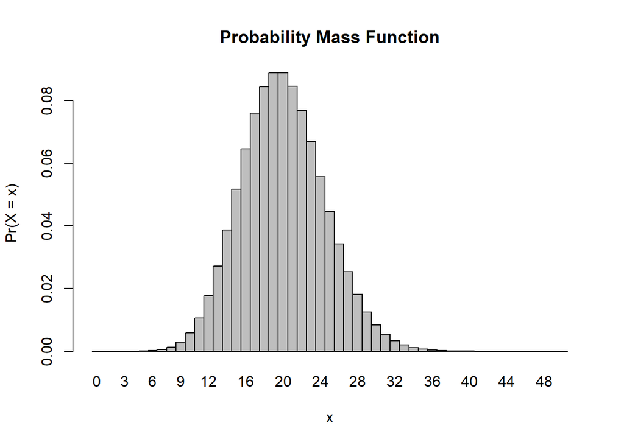

```r
x <- 0:50
l = 20
probset <- dpois(x = x, lambda = l)
barplot(probset, names.arg = x, space = 0, xlab = "x", ylab = "Pr(X = x)", main = "Probability Mass Function")
```

- As we did for other distributions, we can also use the built in probability function for the Poisson distribution, ppois(), to return the value of the cumulative distribution function, i.e., the probability of observing up to and including a specific number of events in the given interval.

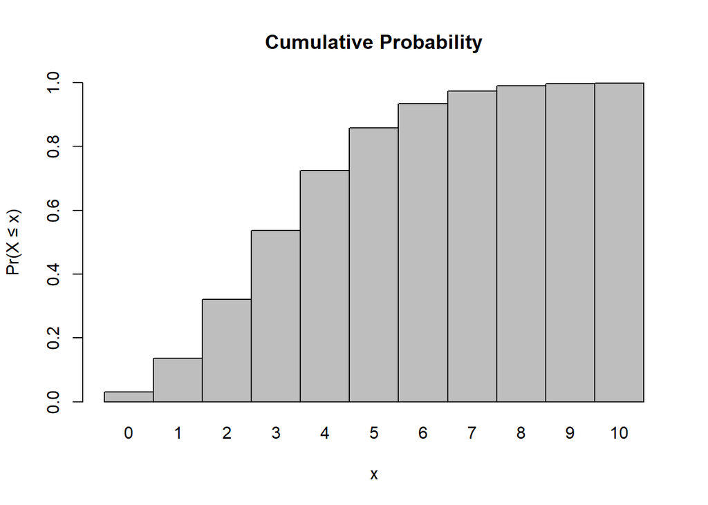

```r
x <- 0:10
l <- 3.5
barplot(ppois(q = x, lambda = l), ylim = 0:1, space = 0, names.arg = x, xlab = "x",
    ylab = "Pr(X ≤ x)", main = "Cumulative Probability")
```

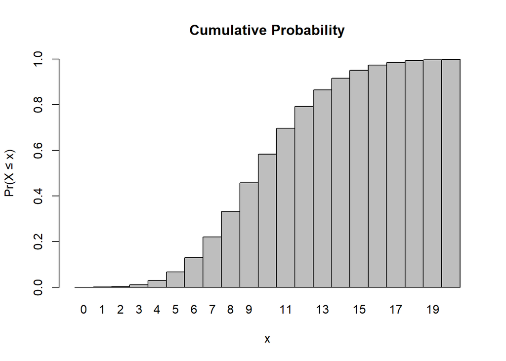

```r
x <- 0:20
l <- 10
barplot(ppois(q = x, lambda = l), ylim = 0:1, space = 0, names.arg = x, xlab = "x",
    ylab = "Pr(X ≤ x)", main = "Cumulative Probability")
```

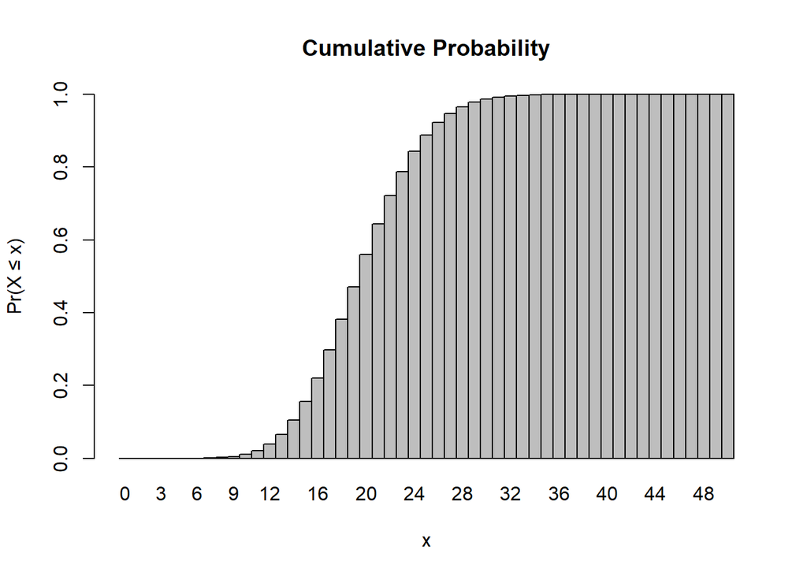

```r
x <- 0:50
l <- 20
barplot(ppois(q = x, lambda = l), ylim = 0:1, space = 0, names.arg = x, xlab = "x",
    ylab = "Pr(X ≤ x)", main = "Cumulative Probability")
```

Probability Density Functions

Uniform Distribution

- The Uniform Distribution is the simplest probability density function describing a continuous random variable. The probability is uniform and does not fluctuate across the range of x values in a given interval.

where a ≤ x ≤ b and 0 for x < a and x > b

(R Challenge 5)

What would you predict the expectation (mean) should be for a uniform distribution?

Let’s plot a uniform distribution across a given range, from a = 4 to b = 8…

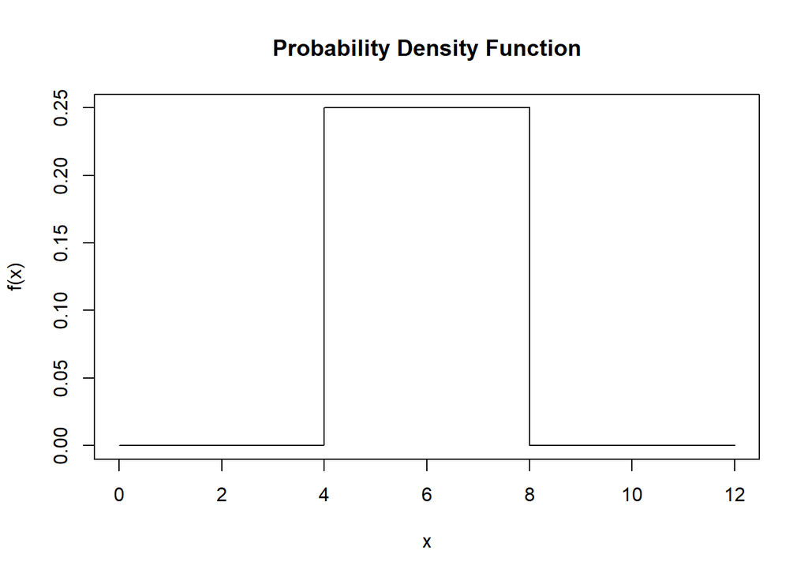

```r
a <- 4
b <- 8
x <- seq(from = a - (b - a), to = b + (b - a), by = 0.01)
fx <- dunif(x, min = a, max = b)  # dunif() evaluates the density at each x
plot(x, fx, type = "l", xlab = "x", ylab = "f(x)", main = "Probability Density Function")
```

- Note that for the uniform distribution, the cumulative density function increases linearly over the given interval.

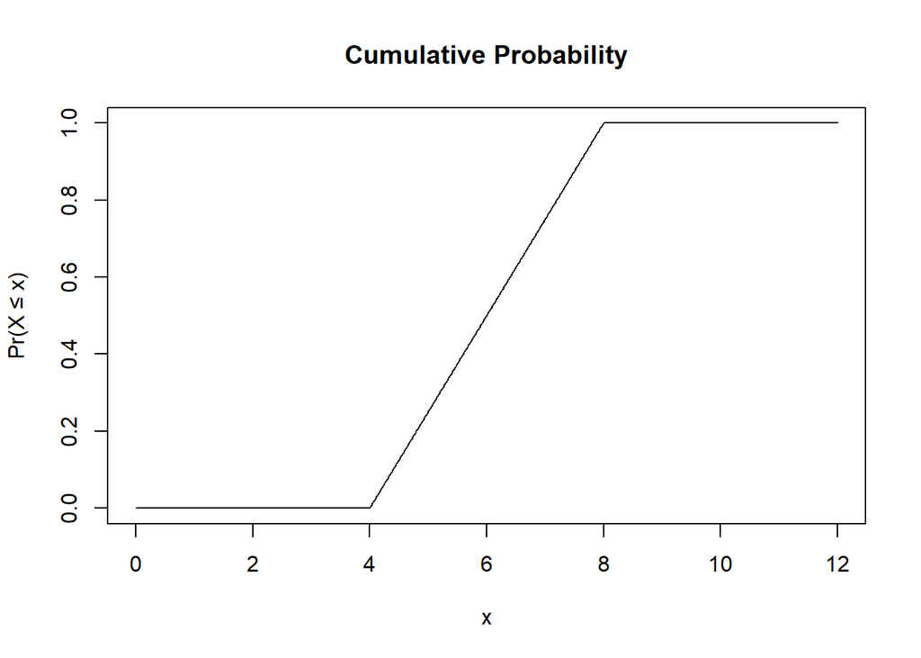

```r
plot(x, punif(q = x, min = a, max = b), type = "l", xlab = "x", ylab = "Pr(X ≤ x)",
    main = "Cumulative Probability")  # punif() is the cumulative probability density up to a given x
```

```r
#Parameters for the uniform distribution
a <- 6
b <- 8

#Simulate a sample of 10,000 random numbers from a uniform distribution
sample_size <- 10000
simulated_sample <- runif(sample_size, min = a, max = b)

#Calculate the mean and variance of the simulated sample
sample_mean <- mean(simulated_sample)
sample_variance <- var(simulated_sample)

#Calculate the theoretical expectation for the uniform distribution
expectation_uniform <- (a + b) / 2

#Results
cat("Sample Mean:", sample_mean, "\n")
```

```
## Sample Mean: 6.989711
```

```r
cat("Sample Variance:", sample_variance, "\n")
```

```
## Sample Variance: 0.3345634
```

Normal Distribution:

- The Normal or Gaussian Distribution is perhaps the most familiar and most commonly applied probability density functions for modeling continuous random variables. Why is the normal so important? Many traits are normally distributed, and the additive combination of many random factors is also commonly normally distributed.
- Two parameters, μ and σ, are used to describe a normal distribution.
- We can get an idea of the shape of a normal distribution with different μ and σ using the simple R code below. Try playing with μ and σ.

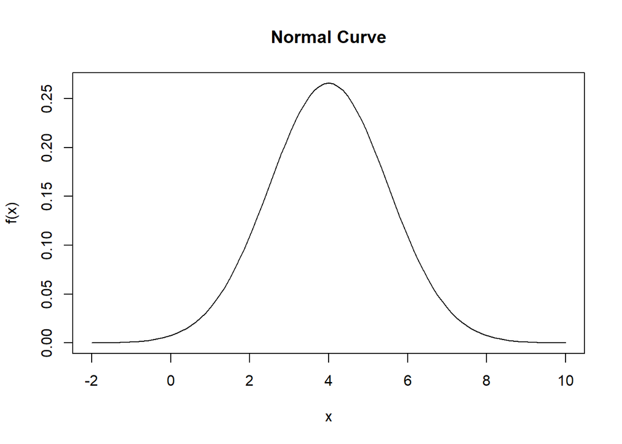

```r
mu <- 4
sigma <- 1.5
curve(dnorm(x, mu, sigma), mu - 4 * sigma, mu + 4 * sigma, main = "Normal Curve",
    xlab = "x", ylab = "f(x)")
```

- You can also use pnorm() to calculate the probability of an observation drawn from the population falling within a particular interval. For example, for a normally distributed population variable with μ = 6 and σ = 2, the probability of a random observation falling between 7 and 8 is…

```r
p <- pnorm(8, mean = 6, sd = 2) - pnorm(7, mean = 6, sd = 2)
p
```

```
## [1] 0.1498823
```

- Likewise, you can use pnorm() to calculate the probability of an observation falling, for example within 2 standard deviations of the mean of a particular normal distribution.

```r
mu <- 0
sigma <- 1
p <- pnorm(mu + 2 * sigma, mean = mu, sd = sigma) - pnorm(mu - 2 * sigma, mean = mu,
    sd = sigma)
p
```

```
## [1] 0.9544997
```

- Regardless of the specific values of μ and σ, about 95% of the normal distribution falls within 2 standard deviations of the mean and about 68% of the distribution falls within 1 standard deviation.

```r
p <- pnorm(mu + 1 * sigma, mean = mu, sd = sigma) - pnorm(mu - 1 * sigma, mean = mu,
    sd = sigma)
p
```

```
## [1] 0.6826895
```

(R Challenge 7)

- Create a vector, v, containing n random numbers selected from a normal distribution with mean μ and standard deviation σ. Use 1000 for n, 3.5 for μ, and 4 for σ. HINT: Such a function exists! rnorm().
- Calculate the mean, variance, and standard deviation for your sample of random numbers.
- Plot a histogram of your random numbers.

```r
n <- 1000
mu <- 3.5
sigma <- 4
v <- rnorm(n, mu, sigma)
mean(v)
```

```
## [1] 3.369273
```

```r
var(v)
```

```
## [1] 14.24274
```

```r
sd(v)
```

```
## [1] 3.773956
```

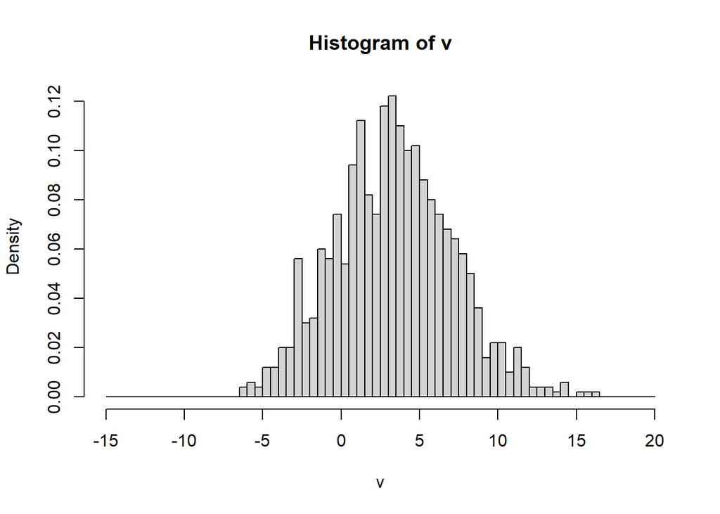

```r
hist(v, breaks = seq(from = -15, to = 20, by = 0.5), probability = TRUE)
```

- A quantile-quantile or “Q-Q” plot can be used to look at whether a set of data seem to follow a normal distribution. A Q–Q plot is a graphical method for generally comparing two probability distributions. To examine a set of data for normality graphically, you plot the quantiles for your actual data (as the y values) versus the theoretical quantiles (as the x values) pulled from a normal distribution. If the two distributions being compared are similar, the points in the plot will approximately lie on the line y = x.
- In this case, this should be apparent since you have simulated a vector of data from a distribution normal distribution.
- To quickly do a Q-Q plot, call the two R functions qqnorm() and qqline() using the vector of data you want to examine as an argument.

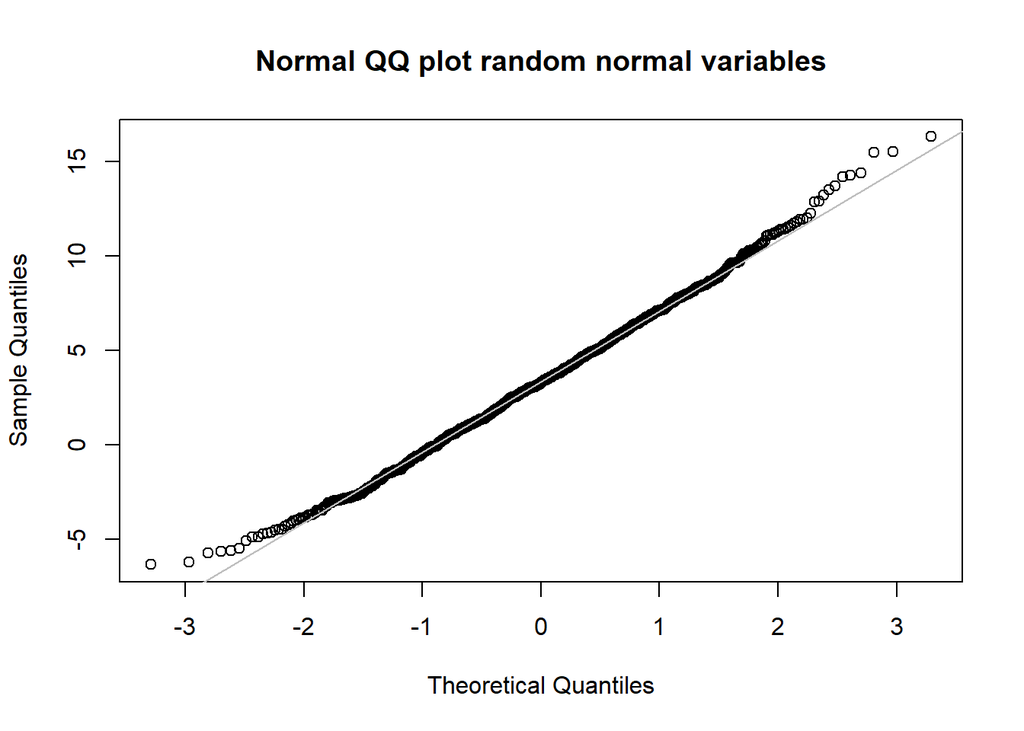

```r
qqnorm(v, main = "Normal QQ plot random normal variables")
qqline(v, col = "gray")
```

This is the same as doing the following:

Step 1: Generate a sequence of probability points in the interval from 0 to 1 equivalent in length to vector v

```r
p <- ppoints(length(v))
head(p)
```

```
## [1] 0.0005 0.0015 0.0025 0.0035 0.0045 0.0055
```

```r
tail(p)
```

```
## [1] 0.9945 0.9955 0.9965 0.9975 0.9985 0.9995
```

Step 2: Calculate the theoretical quantiles for this set of probabilities based on a the distribution you want to compare to (in this case, the normal distribution)

```r
theoretical_q <- qnorm(ppoints(length(v)))
```

Step 3: Calculate the quantiles for your set of observed data for the same number of points

```r
observed_q <- quantile(v, ppoints(v))
```

Step 4: Plot these quantiles against one another

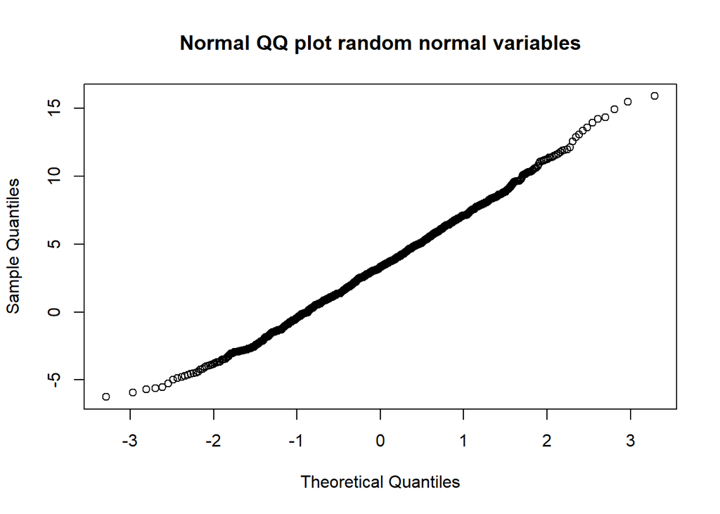

```r
plot(theoretical_q, observed_q, main = "Normal QQ plot random normal variables",
    xlab = "Theoretical Quantiles", ylab = "Sample Quantiles")
```

(R Challenge 8)

- What happens if you simulate fewer observations in your vectors? Or if you simulate observations from a different distribution?

The “Standard Normal” Distribution

- Any normal distribution with mean μ and standard deviation σ can be converted into what is called the standard normal distribution, where the mean is zero and the standard deviation is 1. This is done by subtracting the mean from all observations and dividing these differences by the standard deviation. The resultant values are referred to a Z scores, and they reflect the number of standard deviations an observation is from the mean.

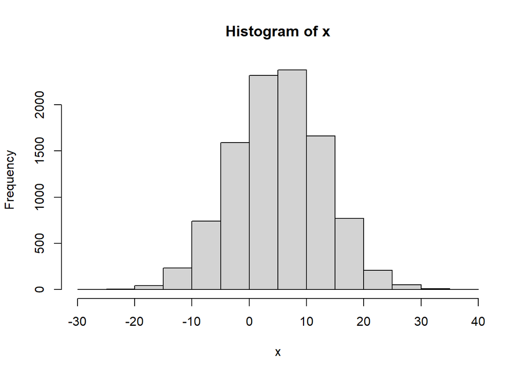

```r
x <- rnorm(10000, mean = 5, sd = 8)  # simulate from a normal distribution with mean 5 and SD 8
hist(x)
```

```r
mean(x)  # really close to 5
```

```
## [1] 5.121761
```

```r
sd(x)  # really close to 8
```

```
## [1] 7.879108
```

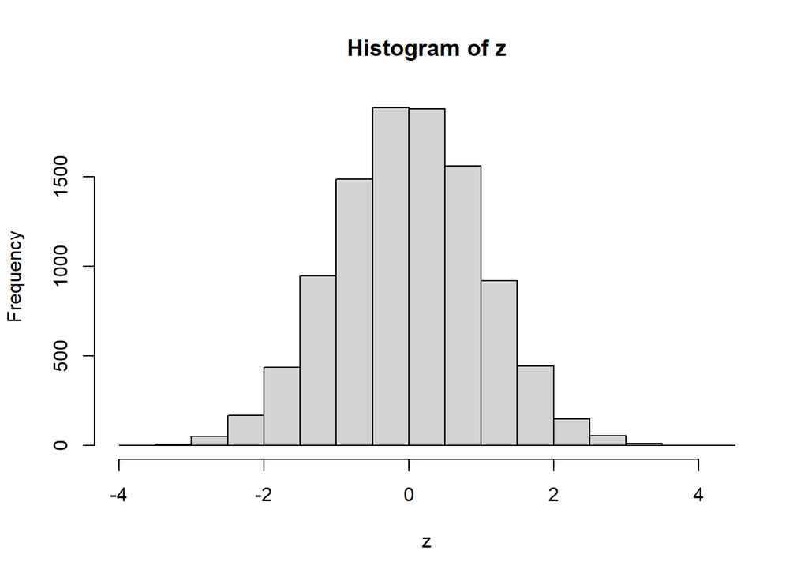

```r
z <- (x - mean(x))/sd(x)  # standardized!
hist(z)
```

```r
mean(z)  # really close to zero
```

```
## [1] 5.199972e-17
```

```r
sd(z)  # really close to 1
```

```
## [1] 1
```

Sample Distributions versus Population Distributions:

- It is important to recognize that, above, we were dealing with probability distributions of discrete and continuous random variables as they relate to populations. But, as we have talked about before, we almost never measure entire populations; instead, we measure samples from populations and we characterize our samples using various statistics. The theoretical probability distributions described above (and others) are models for how we connect observed sample data to populations, taking into account various assumptions, and this is what allows us to do many types of inferential statistics. The most fundamental assumption is that the observations we make are independent from one another and are identically distributed, an assumption often abbreviated as iid. Obvious cases of violation of this assumption are rife in the scientific literature, and we should always be cautious about making this assumption!
- The important thing for us to know is that we can get unbiased estimates of population level parameters on the basis of sample statistics.
- Let’s imagine a population of 1 million zombies whose age at zombification is characterized by a normal distribution with a mean of 25 years and a standard deviation of 5 years. Below, we set up our population:

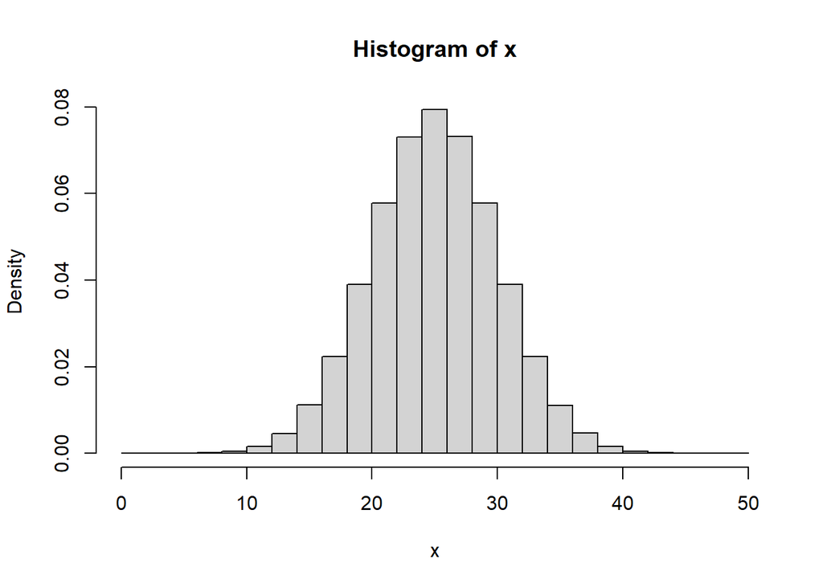

```r
set.seed(1)
x <- rnorm(1e+06, 25, 5)
hist(x, probability = TRUE)
```

```r
mu <- mean(x)
mu
```

```
## [1] 25.00023
```

```r
sigma <- sqrt(sum((x - mean(x))^2)/length(x))
```

```r
k <- 1000  # number of samples
n <- 5  # size of each sample
s <- NULL  # dummy variable to hold each sample
for (i in 1:k) {
    s[[i]] <- sample(x, size = n, replace = FALSE)
}
head(s)
```

```
## [[1]]
## [1] 32.48970 25.31725 25.52090 33.68150 22.90267
##
## [[2]]
## [1] 14.67928 26.26720 23.67120 17.89460 31.55967
##
## [[3]]
## [1] 25.89339 21.30821 24.72550 19.42369 21.29459
##
## [[4]]
## [1] 31.62590 21.86920 20.17409 18.95860 19.58058
##
## [[5]]
## [1] 26.26858 32.64289 32.87201 20.41864 17.69360
##
## [[6]]
## [1] 31.27920 24.54881 26.58940 26.30554 31.34512
```

- For each of these samples, we can then calculate a mean age, which is a statistic describing each sample. That statistic itself is a random variable with a mean and distribution. This is the sampling distribution. How does the sampling distribution compare to the population distribution? The mean of the two is pretty close to the same! The sample mean - which is an average of the set of sample averages - is an unbiased estimator for the population mean.

```r
m <- NULL
for (i in 1:k) {
    m[i] <- mean(s[[i]])
}
mean(m)  # almost equal to...
```

```
## [1] 25.05822
```

```r
mu
```

```
## [1] 25.00023
```

- Again, this is the mean of the sampling distribution, which is simply the average of the means of each sample. This value should be really close to the population mean.

The Standard Error

- The variance in the sampling distribution, i.e., of all possible means of samples of size n from a population, is σ2/n. The square root of this variance is the standard deviation of the sampling distribution, also referred to as the standard error.
- Thus, if the population variance σ2 (and thus the population standard deviation σ) is known, then the standard error can be calculated as square root of (σ2/n) or, equivalently, σ / (square root of the sample size).

```r
pop_se <- sqrt(sigma^2/n)
pop_se  # SE estimated from population standard deviation
```

```
## [1] 2.236481
```

```r
pop_se <- sigma/sqrt(n)
pop_se  # SE estimated from population standard deviation
```

```
## [1] 2.236481
```

- If the true population standard deviation is not known, the standard error can still be estimated from the standard deviation of any given sample. Thus, analogous to the formula we used when the true population standard deviation was known, the standard error calculated from a sample is simply the sample standard deviation / (square root of the sample size), or…

```r
stdev <- NULL
for (i in 1:k) {
    stdev[i] <- sd(s[[i]])
}
sem <- stdev/sqrt(n)  # a vector of SEs estimated from each sample
head(sem)
```

```
## [1] 2.141974 2.995999 1.200017 2.346671 3.094917 1.391291
```

```r
mean(sem)  # which is almost equal to...
```

```
## [1] 2.113435
```

```r
pop_se
```

```
## [1] 2.236481
```

- Thus, the standard error of the mean calculated from an individual sample can be used as an estimator for the standard deviation of the sampling distribution. This is extremely useful, since it means that, if our sample is large enough, we don’t have to repeatedly sample from the population to get an estimate of the sampling distribution directly using our data.
- Note that as our sample size increases, the standard error of the mean should decrease, as should the standard deviation in estimates of the population mean drawn from successive samples. This should be apparent intuitively… as each sample drawn from a population gets larger, the estimate of the mean value of those samples should vary less and less.
- Despite their similarities, the standard error of the mean calculated for a given sample and the standard deviation of that given sample tell us different things. The standard error of the mean is an estimate of how far a given sample mean is likely to be from the population mean; it is a measure of uncertainty. The standard deviation of a sample is a measure of the degree to which individuals values within a sample differ from the sample mean.